# Assignment 1

Hein

2026-06-28

# Loading and preprocessing the data

```r
if (!dir.exists("data")) {
        dir.create("data")
}

url <- "https://d396qusza40orc.cloudfront.net/repdata%2Fdata%2Factivity.zip"
zip_path <- "data/activity.zip"

download.file(url, destfile = zip_path, method = "curl")
unzip(zip_path, exdir = "data")

data <- read.csv("data/activity.csv")
data$date <- as.Date(data$date)

steps <- aggregate(steps ~ date, data = data, FUN = sum, na.rm = TRUE)
head(steps)
```

```
##         date steps
## 1 2012-10-02   126
## 2 2012-10-03 11352
## 3 2012-10-04 12116
## 4 2012-10-05 13294
## 5 2012-10-06 15420
## 6 2012-10-07 11015
```

# What is mean total number of steps taken per day?

## Calculate the total number of steps taken per day.

```r
steps <- aggregate(steps ~ date, data = data, FUN = sum, na.rm = TRUE)
head(steps)
```

```
##         date steps
## 1 2012-10-02   126
## 2 2012-10-03 11352
## 3 2012-10-04 12116
## 4 2012-10-05 13294
## 5 2012-10-06 15420
## 6 2012-10-07 11015
```

## Make a histogram of the total number of steps taken each day.

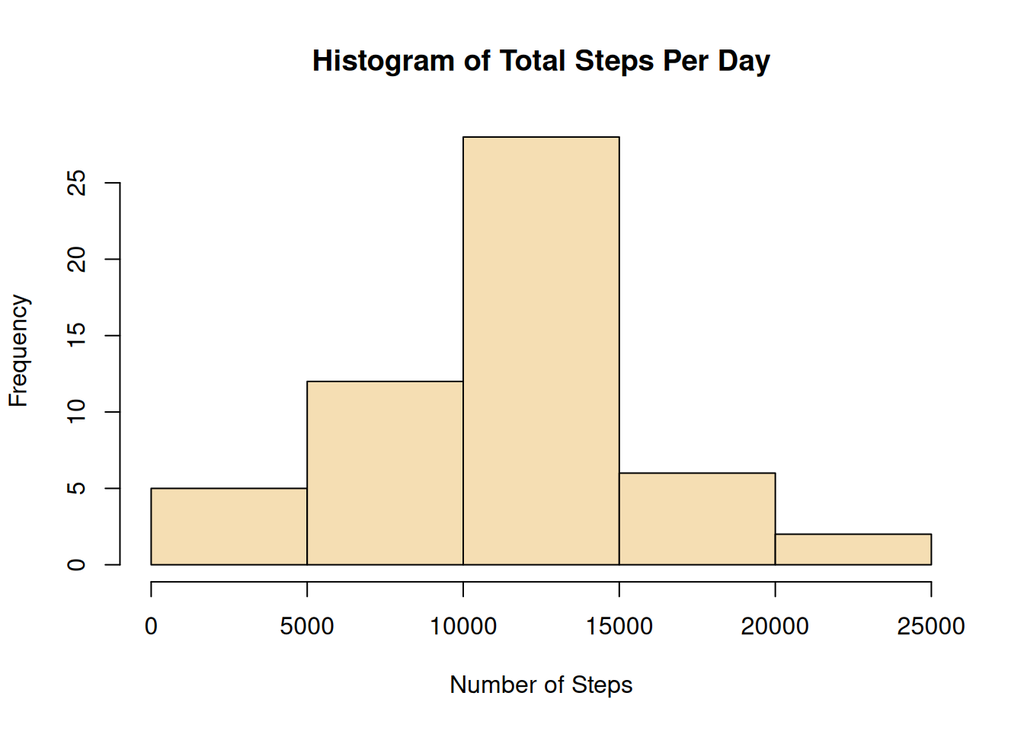

```r
hist(steps$steps,
     main = "Histogram of Total Steps Per Day",
     xlab = "Number of Steps",
     col = "wheat")
```

## Calculate and report the mean and median of the total number of steps taken per day.

```r
mean_steps <- mean(steps$steps)
median_steps <- median(steps$steps)
```

## Make a time series plot (i.e. type = “l”type ) of the 5-minute interval (x-axis) and the average number of steps taken, averaged across all days (y-axis)

```r
intervalSteps <- aggregate (steps ~ interval, data, mean, na.rm = TRUE)
head(intervalSteps)
```

```
##   interval     steps
## 1        0 1.7169811
## 2        5 0.3396226
## 3       10 0.1320755
## 4       15 0.1509434
## 5       20 0.0754717
## 6       25 2.0943396
```

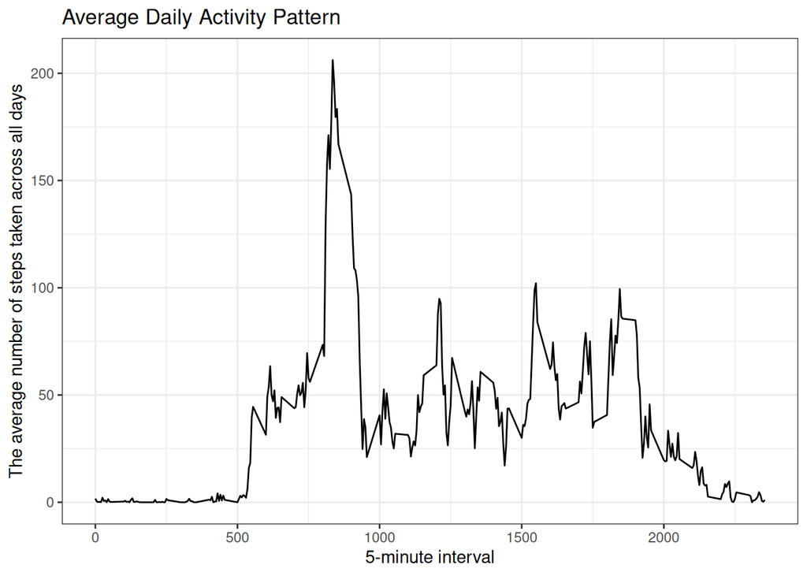

```r
library(ggplot2)
ggplot(intervalSteps,
       aes(x = interval, y = steps)) +
        geom_line() +
        theme_bw() +
        labs(
                title = "Average Daily Activity Pattern",
                x = "5-minute interval",
                y = "The average number of steps taken across all days"
        )
```

## Which 5-minute interval, on average across all the days in the dataset, contains the maximum number of steps?

```r
maxInterval <- intervalSteps[which.max(intervalSteps$steps),]$interval
maxNumSteps <- intervalSteps[which.max(intervalSteps$steps),]$steps
```

5-minute interval **835** contains **206.1698113** as the maximum number steps across all the days in the dataset,.

# Imputing missing values

## Calculate and report the total number of missing values in the dataset (i.e. the total number of rows with NA)

```r
colSums(is.na(data))
```

```
##    steps     date interval
##     2304        0        0
```

```r
rows_NAs <- colSums(is.na(data))[["steps"]]
```

The total number of rows with NA is **2304**.

## Devise a strategy for filling in all of the missing values in the dataset. The strategy does not need to be sophisticated. For example, you could use the mean/median for that day, or the mean for that 5-minute interval, etc. [used - the mean for that 5-minute interval]

## Create a new dataset that is equal to the original dataset but with the missing data filled in.

```r
imputed_data <- data

imputed_data$steps <- ifelse(is.na(imputed_data$steps),
                             intervalSteps$steps[match(imputed_data$interval, intervalSteps$interval)],
                             imputed_data$steps)
```

## Make a histogram of the total number of steps taken each day.

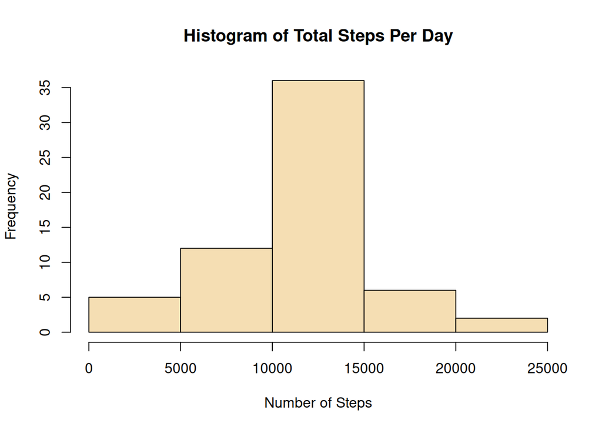

```r
imputed_steps <- aggregate(steps ~ date, imputed_data, FUN = sum)
hist(imputed_steps$steps,
     main = "Histogram of Total Steps Per Day",
     xlab = "Number of Steps",
     col = "wheat")
```

## Calculate and report the mean and median total number of steps taken per day.

```r
mean_imsteps <- mean(imputed_steps$steps)
median_imsteps <- median(imputed_steps$steps)
```

## Do these values differ from the estimates from the first part of the assignment?

```r
# Put your existing variables into a simple comparison grid
data.frame(
        Original   = c(mean_steps, median_steps),
        Imputed    = c(mean_imsteps, median_imsteps),
        Difference = c(mean_imsteps - mean_steps, median_imsteps - median_steps),
        row.names  = c("Mean", "Median")
)
```

```
##        Original  Imputed Difference
## Mean   10766.19 10766.19   0.000000
## Median 10765.00 10766.19   1.188679
```